# Loan Prediction

Ramitha

## 1. Loading data

```r
set.seed(1234)

# install and load all libraries we'll need
load.libraries <- c('knitr','radiant', 'caret', 'RANN','radiant', 'dplyr', 'randomForest')
install.lib <- load.libraries[!load.libraries %in% installed.packages()]
for(libs in install.lib) install.packages(libs, dependences = TRUE)
sapply(load.libraries, require, character = TRUE)
```

```
##        knitr      radiant        caret         RANN      radiant
##         TRUE         TRUE         TRUE         TRUE         TRUE
##        dplyr randomForest
##         TRUE         TRUE
```

```r
# load data in R
train <- read.csv("train.csv", stringsAsFactors = FALSE)
test <- read.csv("test.csv", stringsAsFactors = FALSE)
```

## 2. Data Prep

### 2.a Visualize

```r
str(train)
```

```
## 'data.frame':    614 obs. of  13 variables:
##  $ Loan_ID          : chr  "LP001002" "LP001003" "LP001005" "LP001006" ...
##  $ Gender           : chr  "Male" "Male" "Male" "Male" ...
##  $ Married          : chr  "No" "Yes" "Yes" "Yes" ...
##  $ Dependents       : chr  "0" "1" "0" "0" ...
##  $ Education        : chr  "Graduate" "Graduate" "Graduate" "Not Graduate" ...
##  $ Self_Employed    : chr  "No" "No" "Yes" "No" ...
##  $ ApplicantIncome  : int  5849 4583 3000 2583 6000 5417 2333 3036 4006 12841 ...
##  $ CoapplicantIncome: num  0 1508 0 2358 0 ...
##  $ LoanAmount       : int  NA 128 66 120 141 267 95 158 168 349 ...
##  $ Loan_Amount_Term : int  360 360 360 360 360 360 360 360 360 360 ...
##  $ Credit_History   : int  1 1 1 1 1 1 1 0 1 1 ...
##  $ Property_Area    : chr  "Urban" "Rural" "Urban" "Urban" ...
##  $ Loan_Status      : chr  "Y" "N" "Y" "Y" ...
```

5 numeric cols and 8 factor vars. Loan_ID can be the row name

```r
rownames(train) <- train$Loan_ID
rownames(test) <- test$Loan_ID

train$Loan_ID <- NULL
test$Loan_ID <- NULL

train[train$Gender == "", ]$Gender <- "Male"
test[test$Gender == "", ]$Gender <- "Male"
train$Gender <- factor(train$Gender)
test$Gender <- factor(test$Gender)

train[train$Married == "", ]$Married <- "Yes"
#test[test$Married == "", ]$Married <- "Yes"
train$Married <- factor(train$Married)
test$Married <- factor(test$Married)

train[train$Dependents == "", ]$Dependents <- "0"
test[test$Dependents == "", ]$Dependents <- "0"
train$Dependents <- factor(train$Dependents)
test$Dependents <- factor(test$Dependents)

train$Education <- factor(train$Education)
test$Education <- factor(test$Education)

train[train$Self_Employed == "", ]$Self_Employed <- "No"
test[test$Self_Employed == "", ]$Self_Employed <- "No"
train$Self_Employed <- factor(train$Self_Employed)
test$Self_Employed <- factor(test$Self_Employed)

train[is.na(train$Loan_Amount_Term),]$Loan_Amount_Term <- 360
test[is.na(test$Loan_Amount_Term),]$Loan_Amount_Term <- 360
train$Loan_Amount_Term <- factor(train$Loan_Amount_Term)
test$Loan_Amount_Term <- factor(test$Loan_Amount_Term)

train[is.na(train$Credit_History),]$Credit_History <- "Missing"
test[is.na(test$Credit_History),]$Credit_History <- "Missing"
train$Credit_History <- factor(train$Credit_History)
test$Credit_History <- factor(test$Credit_History)

train$Property_Area <- factor(train$Property_Area)
test$Property_Area <- factor(test$Property_Area)
train$Loan_Status <- factor(train$Loan_Status)
#test$Loan_Status <- factor(test$Loan_Status)

table(train$Loan_Status)
```

```
##
##   N   Y
## 192 422
```

We see that the data is biased for Loan_status = Y. Meaning there are more examples of approved loans than denied ones, which mirrors the reality. So our model may not do well prediction denied loans as it doesn’t have enough examples. Let us see below how we could improve our model for such imbalaced data.

**TRAIN**

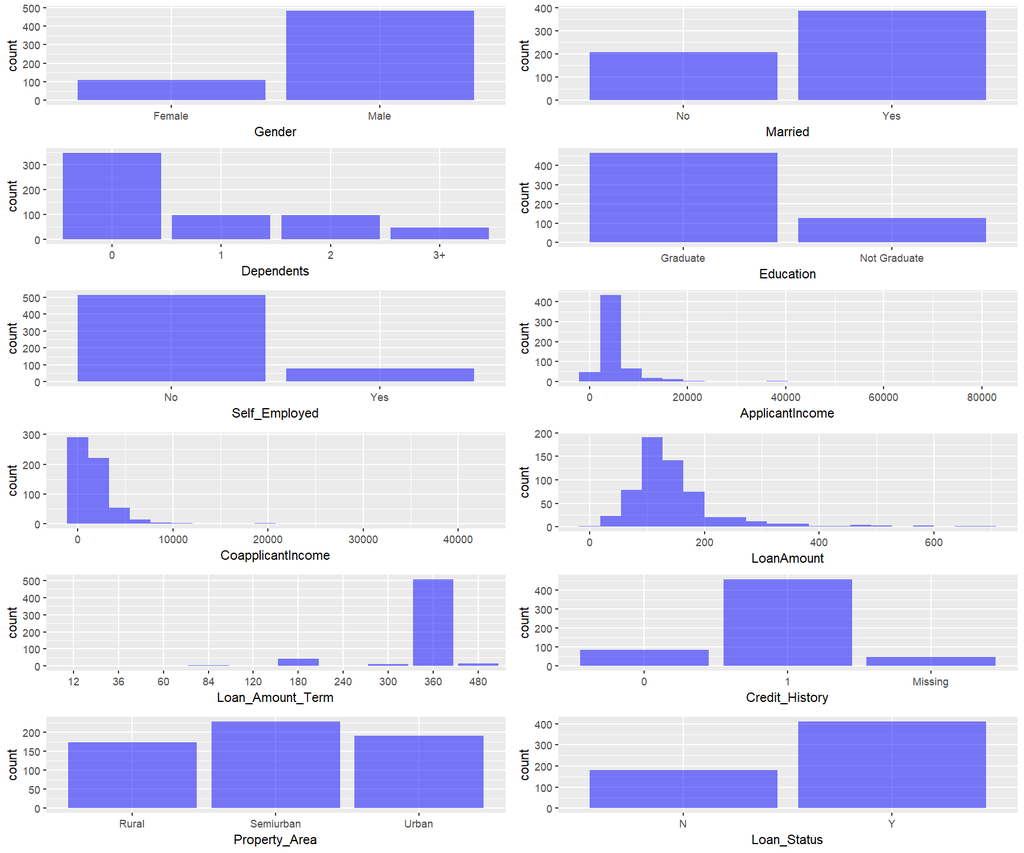

```r
visualize(dataset = "train", xvar = colnames(train),
          yvar = "count", bins = 20, custom = FALSE)
```

**TEST**

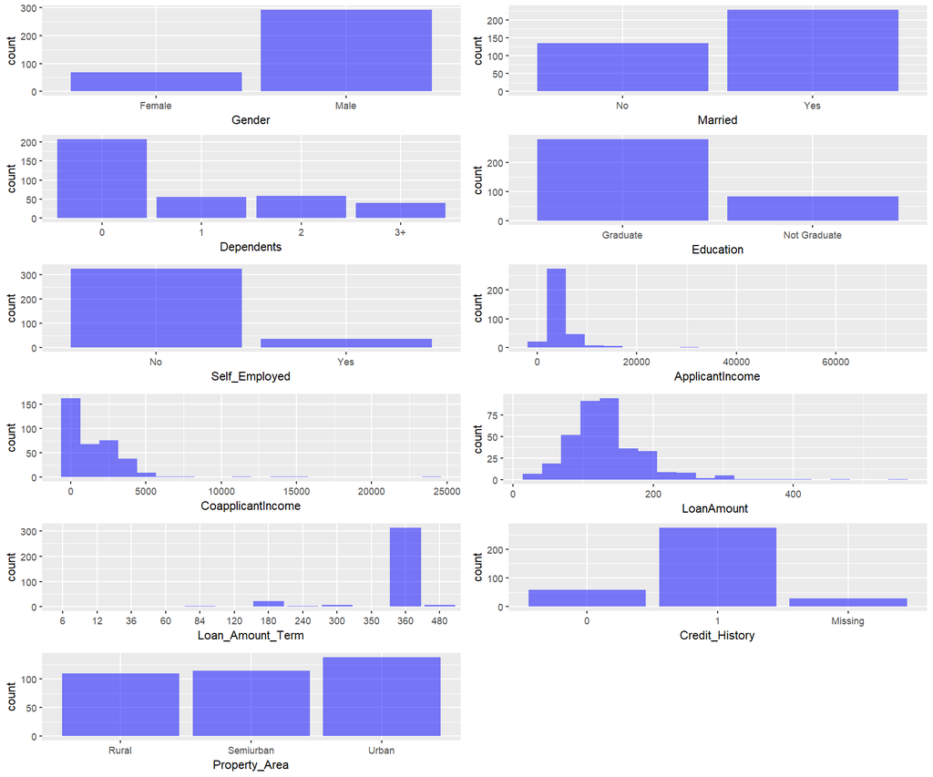

```r
visualize(dataset = "test", xvar = colnames(test),
          yvar = "count", bins = 20, custom = FALSE)
```

### 2.b Missing Values

```r
colSums(is.na(train))
```

```
##            Gender           Married        Dependents         Education
##                 0                 0                 0                 0
##     Self_Employed   ApplicantIncome CoapplicantIncome        LoanAmount
##                 0                 0                 0                22
##  Loan_Amount_Term    Credit_History     Property_Area       Loan_Status
##                 0                 0                 0                 0
```

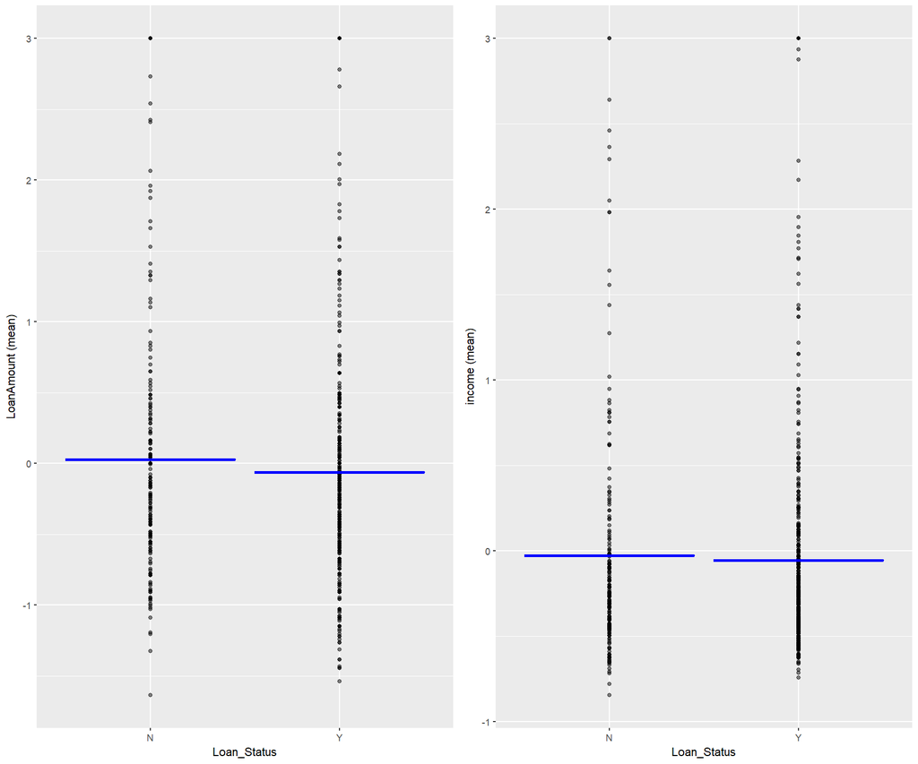

```r
# Fill LoanAmount missing values
train[is.na(train$LoanAmount),]$LoanAmount <- mean(train$LoanAmount, na.rm = TRUE)
test[is.na(test$LoanAmount),]$LoanAmount <- mean(train$LoanAmount, na.rm = TRUE)

# normalise
train$LoanAmount <- (train$LoanAmount - mean(train$LoanAmount)) / sd(train$LoanAmount)
test$LoanAmount <- (test$LoanAmount - mean(train$LoanAmount)) / sd(train$LoanAmount)

# outlier - capped to 3 sigma
train$LoanAmount <- ifelse(train$LoanAmount > 3, 3,
                           ifelse(train$LoanAmount < -3, -3, train$LoanAmount))
test$LoanAmount <- ifelse(test$LoanAmount > 3, 3,
                           ifelse(test$LoanAmount < -3, -3, test$LoanAmount))

## log of ApplicantIncome, CoapplicantIncome and loan amount
# train$LoanAmount <- log(train$LoanAmount)
# test$LoanAmount <- log(test$LoanAmount)

# get single value for Applicant and co-applicant income
train$income <- train$ApplicantIncome + 0.5*train$CoapplicantIncome
test$income <- test$ApplicantIncome + 0.5*test$CoapplicantIncome
train$ApplicantIncome <- NULL
train$CoapplicantIncome <- NULL
test$ApplicantIncome <- NULL
test$CoapplicantIncome <- NULL

# normalise
train$income <- (train$income - mean(train$income)) / sd(train$income)
test$income <- (test$income - mean(train$income)) / sd(train$income)

# outlier
train$income <- ifelse(train$income > 3, 3,
                           ifelse(train$income < -3, -3, train$income))
test$income <- ifelse(test$income > 3, 3,
                           ifelse(test$income < -3, -3, test$income))

# train$income <- log(train$income)
# test$income <- log(test$income)

# center and scale
# preProcValues <- preProcess(train, method = c("knnImpute","center","scale"))

#train_processed <- predict(preProcValues, train)
#colSums(is.na(train_processed))

## same on test
#test_processed <- predict(preProcValues, test)

visualize(
  dataset = "train",
  xvar = "Loan_Status",
  yvar = c("LoanAmount", "income"),
  type = "scatter",
  custom = FALSE)
```

We have also centered and scaled the variables to represent data in terms of mean and sd

### 2.c Creating dummy variables

```r
train_processed <- train
test_processed <- test

# safe guard target from getting converted to dummy vars
train_processed$Loan_Status <- ifelse(train_processed$Loan_Status=='N',0,1)

dmy <- dummyVars(" ~ .", data = train_processed,fullRank = T)
train_processed <- data.frame(predict(dmy, newdata = train_processed))

train_processed$Loan_Status <- as.factor(train_processed$Loan_Status)

## same for test
dmy <- dummyVars(" ~ .", data = test_processed,fullRank = T)
test_processed <- data.frame(predict(dmy, newdata = test_processed))
```

### 2.d Train, Test and Validation set

```r
index <- createDataPartition(train_processed$Loan_Status, p=0.75, list=FALSE)
trainSet <- train_processed[ index,]
testSet <- train_processed[-index,]
```

## 3. Feature Selection

```r
control <- rfeControl(functions = rfFuncs,
                   method = "repeatedcv",
                   repeats = 5,
                   verbose = FALSE)
outcomeName<-'Loan_Status'
predictors <- names(trainSet)[!names(trainSet) %in% outcomeName]
start_time <- Sys.time()
imp_vars <- rfe(trainSet[,predictors],
                trainSet[,outcomeName],
                rfeControl = control) #, sizes=c(1:22))
end_time <- Sys.time()
print(end_time - start_time)
imp_vars
#plot(imp_vars, type=c("g", "o"))
```

[output not shown]

```r
predictors<-c("Credit_History.1", "Credit_History.Missing", "Loan_Amount_Term.480", "income", "Married.Yes", "Property_Area.Semiurban")
```

## 4. Model

```r
model_gbm <- train(trainSet[,predictors],trainSet[,outcomeName],method='gbm')
model_rf <- train(trainSet[,predictors],trainSet[,outcomeName],method='rf')
#model_nnet <- train(trainSet[,predictors],trainSet[,outcomeName],method='nnet')
#model_glm <- train(trainSet[,predictors],trainSet[,outcomeName],method='glm')
```

```r
predictions<-predict.train(object=model_gbm,testSet[,predictors],type="raw")
table(predictions)
```

```
## predictions
##   0   1
##  22 131
```

```r
confusionMatrix(predictions,testSet[,outcomeName])
```

```
## Confusion Matrix and Statistics
##
##           Reference
## Prediction   0   1
##          0  20   2
##          1  28 103
##
##                Accuracy : 0.8039
##                  95% CI : (0.7321, 0.8636)
##     No Information Rate : 0.6863
##     P-Value [Acc > NIR] : 0.0007737
##
##                   Kappa : 0.4662
##  Mcnemar's Test P-Value : 5.01e-06
##
##             Sensitivity : 0.4167
##             Specificity : 0.9810
##          Pos Pred Value : 0.9091
##          Neg Pred Value : 0.7863
##              Prevalence : 0.3137
##          Detection Rate : 0.1307
##    Detection Prevalence : 0.1438
##       Balanced Accuracy : 0.6988
##
##        'Positive' Class : 0
##
```

```r
predictions <- predict.train(object=model_rf,test_processed[,predictors],type="raw")

sub <- as.data.frame(rownames(test))
sub$pred <- predictions
colnames(sub) <- c("Loan_ID", "Loan_Status")
sub$Loan_Status <- ifelse(sub$Loan_Status == 1, "Y", "N")
#write.csv(sub, "rf_6vars.csv", row.names = FALSE)
```

### Undersampling

```r
ctrl <- trainControl(method = "repeatedcv",
                     number = 10,
                     repeats = 5,
                     verboseIter = FALSE,
                     sampling = "down")

# model_rf_under <- caret::train(Loan_Status ~ .,
#                          data = trainSet,
#                          method = "gbm",
#                          preProcess = c("scale", "center"),
#                          trControl = ctrl)

model_rf_under <- train(trainSet[,predictors],trainSet[,outcomeName],method='gbm', trControl = ctrl)

final_under <- data.frame(actual = testSet$Loan_Status,
                    predict(model_rf_under, newdata = testSet[,predictors], type = "prob"))
final_under$predict <- ifelse(final_under$X0 > 0.8, 0, 1)

cm_under <- confusionMatrix(final_under$predict, testSet$Loan_Status)
#cm_under

## Best is 0.8
```

```r
cm_under
```

```
## Confusion Matrix and Statistics
##
##           Reference
## Prediction   0   1
##          0  16   1
##          1  32 104
##
##                Accuracy : 0.7843
##                  95% CI : (0.7106, 0.8466)
##     No Information Rate : 0.6863
##     P-Value [Acc > NIR] : 0.00468
##
##                   Kappa : 0.3926
##  Mcnemar's Test P-Value : 1.767e-07
##
##             Sensitivity : 0.3333
##             Specificity : 0.9905
##          Pos Pred Value : 0.9412
##          Neg Pred Value : 0.7647
##              Prevalence : 0.3137
##          Detection Rate : 0.1046
##    Detection Prevalence : 0.1111
##       Balanced Accuracy : 0.6619
##
##        'Positive' Class : 0
##
```

```r
final_under <- predict(model_rf, newdata = test_processed[,predictors], type = "prob")

final_under$predict <- ifelse(final_under$`0` > 0.65, 0, 1)

sub <- as.data.frame(rownames(test))
sub$pred <- final_under$predict
colnames(sub) <- c("Loan_ID", "Loan_Status")
sub$Loan_Status <- ifelse(sub$Loan_Status == 1, "Y", "N")
write.csv(sub, "rf_best.csv", row.names = FALSE)
```

### Parameter Tuning

```r
modelLookup(model='rf')
```

|  | model | parameter | label | forReg | forClass | probModel |
| --- | --- | --- | --- | --- | --- | --- |
| 1 | rf | mtry | #Randomly Selected Predictors | TRUE | TRUE | TRUE |

```r
# For rf
grid <- expand.grid(.mtry=c(1:5))

# For gbm
# grid <- expand.grid(n.trees=c(10,20,50,100,500,1000),
#                     shrinkage=c(0.01,0.05,0.1,0.5),
#                     n.minobsinnode = c(3,5,10),
#                     interaction.depth=c(1,5,10))

ctrl <- trainControl(method = "repeatedcv",
                     number = 10,
                     repeats = 5,
                     verboseIter = FALSE,
                     sampling = "down")

model_rf <- train(trainSet[,predictors],
                   trainSet[,outcomeName],
                   method='rf',
                   trControl=ctrl,
                   tuneGrid=grid)
#print(model_gbm)

#plot(model_gbm)
```

```r
model_rf
```

```
## Random Forest
##
## 461 samples
##   6 predictor
##   2 classes: '0', '1'
##
## No pre-processing
## Resampling: Cross-Validated (10 fold, repeated 5 times)
## Summary of sample sizes: 415, 416, 415, 414, 416, 414, ...
## Addtional sampling using down-sampling
##
## Resampling results across tuning parameters:
##
##   mtry  Accuracy   Kappa
##   1     0.7817256  0.4583732
##   2     0.7826321  0.4537742
##   3     0.7794832  0.4515972
##   4     0.7592725  0.4277624
##   5     0.7246704  0.3902429
##
## Accuracy was used to select the optimal model using  the largest value.
## The final value used for the model was mtry = 2.
```

```r
final_under <- predict(model_rf, newdata = test_processed[,predictors], type = "prob")

final_under$predict <- ifelse(final_under$`0` > 0.65, 0, 1)

sub <- as.data.frame(rownames(test))
sub$pred <- final_under$predict
colnames(sub) <- c("Loan_ID", "Loan_Status")
sub$Loan_Status <- ifelse(sub$Loan_Status == 1, "Y", "N")
write.csv(sub, "rf_tuned.csv", row.names = FALSE)
```